# Coursera Practical machine learning programming assignment

Peter B.

17 Juni 2018

## Synopsis

### Background information and assignment instructions

Using devices such as Jawbone Up, Nike FuelBand, and Fitbit it is now possible to collect a large amount of data about personal activity relatively inexpensively. These type of devices are part of the quantified self movement - a group of enthusiasts who take measurements about themselves regularly to improve their health, to find patterns in their behavior, or because they are tech geeks. One thing that people regularly do is quantify how much of a particular activity they do, but they rarely quantify how well they do it. In this project, your goal will be to use data from accelerometers on the belt, forearm, arm, and dumbell of 6 participants. They were asked to perform barbell lifts correctly and incorrectly in 5 different ways. More information is available from the website here: http://groupware.les.inf.puc-rio.br/har (see the section on the Weight Lifting Exercise Dataset).

### Data

The training data for this project are available here: https://d396qusza40orc.cloudfront.net/predmachlearn/pml-training.csv The test data are available here: https://d396qusza40orc.cloudfront.net/predmachlearn/pml-testing.csv

Data source: http://groupware.les.inf.puc-rio.br/har [last accessed: 15June2018] more details can be found here: Velloso, E.; Bulling, A.; Gellersen, H.; Ugulino, W.; Fuks, H. Qualitative Activity Recognition of Weight Lifting Exercises. Proceedings of 4th International Conference in Cooperation with SIGCHI (Augmented Human ’13) . Stuttgart, Germany: ACM SIGCHI, 2013.

### Assigment

The goal of your project is to predict the manner in which they did the exercise. This is the “classe” variable in the training set. You may use any of the other variables to predict with. You should create a report describing how you built your model, how you used cross validation, what you think the expected out of sample error is, and why you made the choices you did. You will also use your prediction model to predict 20 different test cases.

## Summary

After reading the datasets a basic exploratory data analyses is performed. In a next step empty variables are excluded as well as variables with a zero or close to zero variance that won’t conribute to a model.The training data is for cross-validation purposes partioned in a test and training data set. In a first step a decision tree model is applied. The accurany with 0.7 is not conincing. So a random forest model is used. Here an accuracy of 0.98 is obtained. The expected out of sample rate is 2.3% and acceptable.

## Programming part

### Getting the data

```r
#fileUrl <- "https://d396qusza40orc.cloudfront.net/predmachlearn/pml-training.csv"
#download.file(fileUrl, destfile= paste0(getwd(), "pml-training.csv"))
training0 <- read.csv(paste0(getwd(), "pml-training.csv"))

#fileUrl <- "https://d396qusza40orc.cloudfront.net/predmachlearn/pml-testing.csv"
#download.file(fileUrl, destfile= paste0(getwd(), "pml-testing.csv"))
testing0 <- read.csv(paste0(getwd(), "pml-testing.csv"))
```

### Explorative data analyses

To get an first impression of the available data explorative data analyses tools are used to summarize the data and get information and variable types etc. For readablity purposes only the codeis shown in the submission.

```r
# str(training0)
# dim(training0)
# summary(training0)
```

### Cleaning data

In this part of the assignment - all empty and not model suited variables are removed. The variables that are not suitable in the modeling are: “X”, “user_name”, “raw_timestamp_part_1”, “raw_timestamp_part_2”, “cvtd_timestamp”, “new_window”, “num_window” and the variables that are empty are statistics related (mean, standard deviation, skewness, kurtosis and variance). So all variables that are usable will be kept and in a next step those variables will be kept in both - training and testing - data sets. - in a second step all variables that do not conribute based on a varianve close to zero or zero will be removed as they do also not conribute to a model fitting using the nearZeroVar function from the caret package.

```r
# remove variables with only missing values
colSums(is.na(training0))
```

[output not shown]

[output cut: 53 more lines]

[output not shown]

```r
keepVar <- names(training0[,colSums(is.na(training0)) == 0])
keepVar2 <- keepVar[8:59]

training1 <- training0[,c(keepVar2,"classe")]
testing1  <- testing0[,c(keepVar2,"problem_id")]

# remove variables with a variance close to zero
NZV <- nearZeroVar(training1)
training2 <- training1[, -NZV]
testingFinal  <- testing1[, -NZV]
dim(training2); dim(testingFinal)
```

```
## [1] 19622    30
```

```
## [1] 20 30
```

Using this two approaches the input dataset for the modeling is reduced from 160 variables to 30 variables.

### Partioning the data

The “training” data set will be split into a training data set containing 60% of the observations and a testing data set (40% of the total cases) bases on the outcome variable “classe”. This will allow us to perform a cross-validation and estimate the out of sample error. For reproducibilty purposes we will also set a seed, here: 999.

```r
set.seed(999)
library(caret)
inTrain  <- createDataPartition(training2$classe, p=0.6, list=FALSE)
training <- training2[inTrain,]
testing  <- training2[-inTrain,]
dim(training);dim(testing)
```

```
## [1] 11776    30
```

```
## [1] 7846   30
```

### Correlation

```r
corrMatrix <- cor(training2[, -30])
```

### prediction modelling

In this step a decision tree as starting point is used and relevant statistics examined

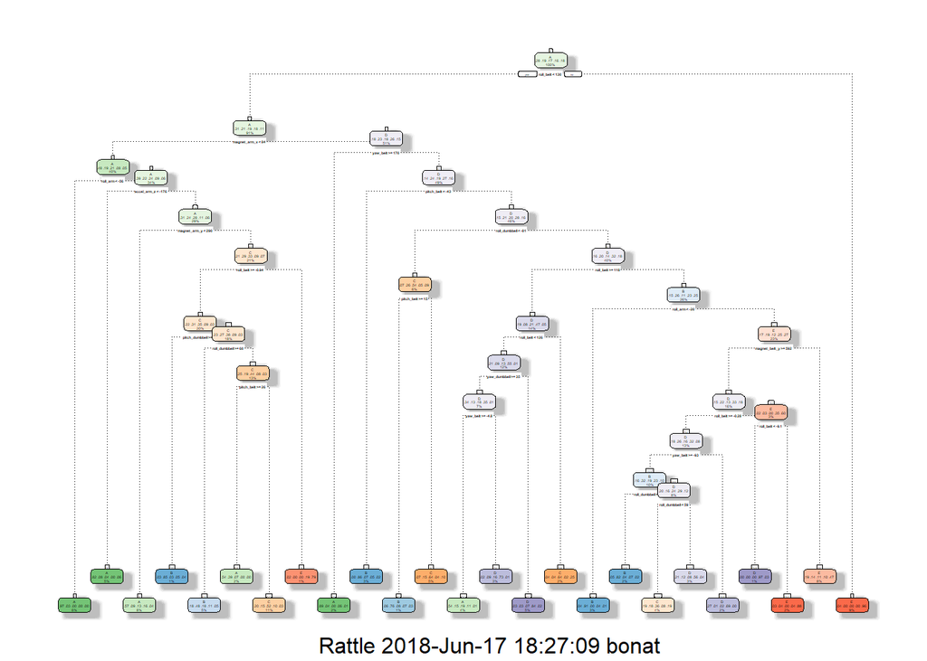

```r
set.seed(999)
library(rpart)
library(rpart.plot)
modFit <- rpart(classe ~ ., data = training, method="class")
fancyRpartPlot(modFit)
```

```r
set.seed(999)
prediction <- predict(modFit, testing, type = "class")
confusionMatrix(prediction, testing$classe)
```

```
## Confusion Matrix and Statistics
##
##           Reference
## Prediction    A    B    C    D    E
##          A 1598  218  183  144   65
##          B   88  835   95   83   46
##          C  261  286  947  163  157
##          D  129   84   85  824   26
##          E  156   95   58   72 1148
##
## Overall Statistics
##
##                Accuracy : 0.6821
##                  95% CI : (0.6717, 0.6924)
##     No Information Rate : 0.2845
##     P-Value [Acc > NIR] : < 2.2e-16
##
##                   Kappa : 0.5984
##  Mcnemar's Test P-Value : < 2.2e-16
##
## Statistics by Class:
##
##                      Class: A Class: B Class: C Class: D Class: E
## Sensitivity            0.7159   0.5501   0.6923   0.6407   0.7961
## Specificity            0.8913   0.9507   0.8662   0.9506   0.9405
## Pos Pred Value         0.7237   0.7280   0.5221   0.7178   0.7508
## Neg Pred Value         0.8875   0.8980   0.9302   0.9310   0.9535
## Prevalence             0.2845   0.1935   0.1744   0.1639   0.1838
## Detection Rate         0.2037   0.1064   0.1207   0.1050   0.1463
## Detection Prevalence   0.2814   0.1462   0.2312   0.1463   0.1949
## Balanced Accuracy      0.8036   0.7504   0.7792   0.7957   0.8683
```

A Random Forest model is created. Here a control dataset is used with the method cv and the number of resampling is set to three.

```r
#set.seed(999)
#modFitRF <- randomForest(classe ~ ., data = training, ntree = 500)
#prediction <- predict(modFitRF, testing, type = "class")
#confusionMatrix(prediction, testing$classe)


set.seed(999)
controlRf <- trainControl(method="cv", number=3, verboseIter=FALSE)
modFitRF2<- train(classe ~ ., data=training, method="rf",
                          trControl=controlRf)
modFitRF2$finalModel
```

```
##
## Call:
##  randomForest(x = x, y = y, mtry = param$mtry)
##                Type of random forest: classification
##                      Number of trees: 500
## No. of variables tried at each split: 2
##
##         OOB estimate of  error rate: 2.32%
## Confusion matrix:
##      A    B    C    D    E class.error
## A 3299   12   15   21    1  0.01463560
## B   37 2211   25    5    1  0.02983765
## C    6   41 1994   12    1  0.02921130
## D    9    2   52 1860    7  0.03626943
## E    1    7   12    6 2139  0.01200924
```

```r
# prediction on Test dataset
set.seed(999)
predictRF <- predict(modFitRF2, newdata=testing)
confusionMatRF <- confusionMatrix(predictRF, testing$classe)
confusionMatRF
```

```
## Confusion Matrix and Statistics
##
##           Reference
## Prediction    A    B    C    D    E
##          A 2199   26    4    2    5
##          B    7 1474   14    0   10
##          C    9   13 1341   48    7
##          D   17    5    9 1236    2
##          E    0    0    0    0 1418
##
## Overall Statistics
##
##                Accuracy : 0.9773
##                  95% CI : (0.9738, 0.9805)
##     No Information Rate : 0.2845
##     P-Value [Acc > NIR] : < 2.2e-16
##
##                   Kappa : 0.9713
##  Mcnemar's Test P-Value : 4.142e-13
##
## Statistics by Class:
##
##                      Class: A Class: B Class: C Class: D Class: E
## Sensitivity            0.9852   0.9710   0.9803   0.9611   0.9834
## Specificity            0.9934   0.9951   0.9881   0.9950   1.0000
## Pos Pred Value         0.9835   0.9794   0.9457   0.9740   1.0000
## Neg Pred Value         0.9941   0.9931   0.9958   0.9924   0.9963
## Prevalence             0.2845   0.1935   0.1744   0.1639   0.1838
## Detection Rate         0.2803   0.1879   0.1709   0.1575   0.1807
## Detection Prevalence   0.2850   0.1918   0.1807   0.1617   0.1807
## Balanced Accuracy      0.9893   0.9831   0.9842   0.9780   0.9917
```

Using the test data set for cross- validation an accuracy of 0.98 is obtained. Though there might be still a tendency to overfitting, this model will be used as final model. The expected out of sample error is 2,32 %.

### Conclusion

See summary at the beginning of the document.

### Applying Random forest predcition to the provided 20 test cases

```r
predictSubm <- predict(modFitRF2, newdata=testingFinal)
predictSubm
```

```
##  [1] B A B A A E D B A A B C B A E E A B B B
## Levels: A B C D E
```